# Text Mining in R

# R Text Mining Workshop

Scenario : The president of a travel company would like to know about the travel characteristics of Italy, i.e. activities/customer perspective on the destinations. He asks you to give him insights about Italy regions in 3 hours.

You spent the first hour considering your ressources. You found an open source travel guide wikivoyage. It provides a data dump of its pages https://dumps.wikimedia.org/enwikivoyage/20170120/. You downloaded it and put each region content in a list called italy.

### Load the scrapes of Wikitravels:

```r
load('workshop_data.RData')
```

### Contents

```r
names(italy)
```

```
##  [1] "Piedmont"             "Liguria"              "Lombardy"
##  [4] "Aosta_Valley"         "EmiliaRomagna"        "FriuliVenezia_Giulia"
##  [7] "TrentinoAlto_Adige"   "Veneto"               "Lazio"
## [10] "Abruzzo"              "Marche"               "Tuscany"
## [13] "Umbria"               "Apulia"               "Basilicata"
## [16] "Calabria"             "Campania"             "Molise"
## [19] "Sicily"               "Sardinia"
```

Shows the first region “Piedmont” description.

As you can see, it’s a messy text with symbols and numbers.

```r
substr(italy[1], 1, 1000)
```

```
## [1] "{{pagebanner|Pagebanner default.jpg|unesco=yes}}\n{{otheruses}}\n\n[[ image:ItalyPiemont.png|right|noborder|250px]]\n\n'''Piedmont''' (Italian: ''Piemonte'') is a region in the northwest of [[Italy]], next to the border with [[France]]. The main city is [[Turin]] (''Torino''), which was host…
```

# The Right Tools

The content is not really structured, the region descriptions are to be found across the different sections. To extract meaning, we will use techniques that represent documents as bag-of-words (documents are described based on the words that occur in them and how often they occur). Loading the Text Mining package.

```r
# Online Install
# install.packages("devtools")
# library(devtools)
# install_version("tm", version = "0.6-2", repos = "http://cran.us.r-project.org")
# install.packages("SnowballC")

# load the package
library(tm) #tm for text mining
# Check the version
help(package="tm")
```

# Preprocessing : Data Cleaning

First, we create a corpus (collection of documents that will be processed together):

Each page scrape is represented as a document in a corpus. It reaches a bag-of-words form thanks to a tokenizer that splits the page strings in tokens/words (the basic principle being that a whitespace indicates a separation between tokens). Let us check how well it describes a simple example

### Example

```r
a_list_of_words <- c("cat cats cat, whiskers", "cat Cat dog parrot turtle", "cat ate dog")

test_corpus <- Corpus(VectorSource(a_list_of_words))

as.matrix(DocumentTermMatrix( test_corpus ) )
```

```
##     Terms
## Docs cat cats whiskers dog parrot turtle ate
##    1   2    1        1   0      0      0   0
##    2   2    0        0   1      1      1   0
##    3   1    0        0   1      0      0   1
```

```r
#help(DocumentTermMatrix)
```

```r
# Display the name of available transformations in the console
getTransformations()
```

```
## [1] "removeNumbers"     "removePunctuation" "removeWords"
## [4] "stemDocument"      "stripWhitespace"
```

```r
help("removeNumbers")  #Remove numbers from a text document.
```

### Transform your corpus

```r
# first assign it
corpus = Corpus(VectorSource( unlist(italy) ))
```

The cleaning starts now:

```r
# Create a function that can replace matched regular expressions. content_transformer is used to apply any function taking string

# as input and returning string on our corpus
replacer <- content_transformer( function(x, pattern, replacement) gsub(pattern, replacement, x) )

# help(content_transformer)
# help(tm_map)

# Remove unnecessary sections
corpus <- tm_map(corpus, replacer, "Go next.*", " ")

# Create function that lowers everything because 'House' and 'house' should count as the same unit
lowerer <- content_transformer(function(x) tolower(x))

# Lowers everything
corpus <- tm_map(corpus, lowerer) # note : unecessary actually because of the tokenizer of tm package

# remove punctuations
corpus <- tm_map(corpus, removePunctuation)

# remove meaningless words
corpus <- tm_map(corpus, removeWords, tm::stopwords("SMART"))

# remove region names
corpus <- tm_map(corpus,removeWords, tolower(names(italy)))

# remove extra whitespace : note \n are removed
corpus <- tm_map(corpus, stripWhitespace)

# Transform variations of same root into a single root ( ex: beaches -> beach, beach -> beach)
corpus <- tm_map(corpus, stemDocument,language="english")
```

The result:

```r
substr(as.character( corpus[[1]] ), 1, 2000 )
```

```
## [1] "pagebannerpagebann defaultjpgunescoy otherus imageitalypiemontpngrightnoborder250px italian piemont region northwest itali border franc main citi turin torino host 2006 winter olymp game surround side alp includ monviso po river rise mont rosa border franc switzerland italian region aosta va…
```

```r
## view all
# as.character(corpus[[1]])

# typeof(corpus)
# corpus is a list of text, changing it to character to view it in R
```

# Define the right bag of words

We want to keep the words that are meaningful and that will help describe and compare the regions. Let us first create a DocumentTerm matrix with this corpus.

```r
# Bag of word representation of the corpus
dtm = DocumentTermMatrix(corpus)
```

Words with frequency more than 30

```r
# Words that occurs more than 30 times
findFreqTerms(dtm, lowfreq=30)
```

```
##  [1] "airport"  "ancient"  "area"     "beauti"   "bus"      "car"
##  [7] "centuri"  "citi"     "connect"  "destin"   "direct"   "drink"
## [13] "famous"   "found"    "great"    "hill"     "hour"     "includ"
## [19] "itali"    "italian"  "lake"     "larg"     "local"    "long"
## [25] "made"     "main"     "mont"     "mountain" "nation"   "north"
## [31] "park"     "part"     "peopl"    "price"    "produc"   "provinc"
## [37] "region"   "road"     "roman"    "site"     "ski"      "small"
## [43] "south"    "summer"   "tourist"  "town"     "train"    "valley"
## [49] "white"    "wine"     "world"    "beach"    "coast"    "island"
## [55] "popular"  "run"      "san"      "sea"      "travel"   "villag"
## [61] "visit"    "offer"    "rome"     "ticket"   "—"        "march"
```

We have selected words that seem meaningful and group synonyms together (for instance duomo is an italian cathedral chuch and should count as the same thing as a cathedral or church). The result is available in the dictionary provided. Let us transform synonyms into a single form

```r
replace.synonyms<-function(x,dictionary) {
  for (main in names(dictionary)) {
    for (syn in dictionary[[main]]) {
      x=gsub(paste("",syn,""),paste("",main,""),x)
    }
  }
  return(x)
}

# Transform synonymns into one single form
corpus <- tm_map(corpus,content_transformer(replace.synonyms),dictionary)
```

# Computing term frequencies

Let us create a bag-of-words representation of our documents with the meaningful terms we have kept

```r
options(digits=3)

#Compute the term frequencies, filtered
dtm <- DocumentTermMatrix(corpus, control=list(dictionary=names(dictionary)))
rownames(dtm) <- names(italy)  #give documents their names

#display it
mat <- as.matrix(dtm)
mat[,1:10]
```

```
##                       Terms
## Docs                   ancient art church hiking historic medieval
##   Piedmont                   3   1      1      1        1        1
##   Liguria                    0   3      0      1        0        0
##   Lombardy                   1   2      1      1        1        2
##   Aosta_Valley               1   1      1      2        2        0
##   EmiliaRomagna              2   1      0      0        1        1
##   FriuliVenezia_Giulia       1   0      0      0        0        0
##   TrentinoAlto_Adige         0   1      0      2        0        0
##   Veneto                     1   1      0      0        0        1
##   Lazio                      1   0      0      0        0        0
##   Abruzzo                    3   1      3      3        4        5
##   Marche                     5   7      2      5        9       11
##   Tuscany                    2   6      7      0        0        1
##   Umbria                     2   3      3      0        0        3
##   Apulia                     0   0      0      0        0        0
##   Basilicata                 0   0      0      0        0        0
##   Calabria                   1   0      2      0        1        0
##   Campania                   4   0      0      0        1        0
##   Molise                     0   0      0      0        0        0
##   Sicily                     2   2      0      0        3        0
##   Sardinia                   1   1      2      5        3        3
##                       Terms
## Docs                   mountain museum park ski
##   Piedmont                    1      3    1   4
##   Liguria                     0      1    0   0
##   Lombardy                    2      0    0   3
##   Aosta_Valley                4      0    3   4
##   EmiliaRomagna               6      0    2   0
##   FriuliVenezia_Giulia        2      0    3   2
##   TrentinoAlto_Adige          0      1    0   5
##   Veneto                      0      0    0   1
##   Lazio                       1      1    0   0
##   Abruzzo                    18      6   16  10
##   Marche                     12      7   11   1
##   Tuscany                     2      5   31   0
##   Umbria                      1      1    0   0
##   Apulia                      0      0    1   0
##   Basilicata                  0      0    0   0
##   Calabria                    0      0    0   0
##   Campania                    0      0    4   0
##   Molise                      0      0    0   0
##   Sicily                      4      1    5   0
##   Sardinia                    2      1    1   1
```

# Topic / Theme Extraction

The features are quite granular. Besides, some words are similar to one another. For instance, if a destination is historical, the word ancient is likely to appear is well. Let us check if some words are correlated. If this is the case, we might attempt to reduce all our words to a smaller set of topics or themes.

# Correlation Heat Map

To compute correlation in R, we use the command cor(). It will return a matrix with the correlation coefficients.

```r
cor.mat <- cor(mat)
# plot_df <- cor(df[-1])
head(cor.mat)
```

```
##          ancient   art church hiking historic medieval mountain museum
## ancient    1.000 0.481  0.324  0.349    0.692    0.670    0.585  0.655
## art        0.481 1.000  0.631  0.381    0.530    0.660    0.347  0.715
## church     0.324 0.631  1.000  0.205    0.186    0.356    0.298  0.633
## hiking     0.349 0.381  0.205  1.000    0.774    0.736    0.563  0.556
## historic   0.692 0.530  0.186  0.774    1.000    0.873    0.752  0.681
## medieval   0.670 0.660  0.356  0.736    0.873    1.000    0.721  0.767
##           park    ski  beach garden   sea castle countryside  opera
## ancient  0.436  0.169 0.2611 0.1544 0.344  0.449       0.485 0.5002
## art      0.632 -0.089 0.0715 0.6963 0.443  0.281       0.768 0.6185
## church   0.822  0.128 0.3214 0.6754 0.293  0.407       0.677 0.0632
## hiking   0.158  0.430 0.6738 0.0000 0.736  0.608       0.116 0.4982
## historic 0.294  0.252 0.5081 0.0396 0.690  0.576       0.331 0.7250
## medieval 0.337  0.245 0.5195 0.1522 0.563  0.629       0.464 0.8059
##          cultural painting renaissance
## ancient     0.397   0.3603       0.490
## art         0.462   0.6596       0.872
## church      0.283   0.7990       0.667
## hiking      0.155   0.0886       0.316
## historic    0.494   0.2044       0.502
## medieval    0.194   0.3152       0.595
```

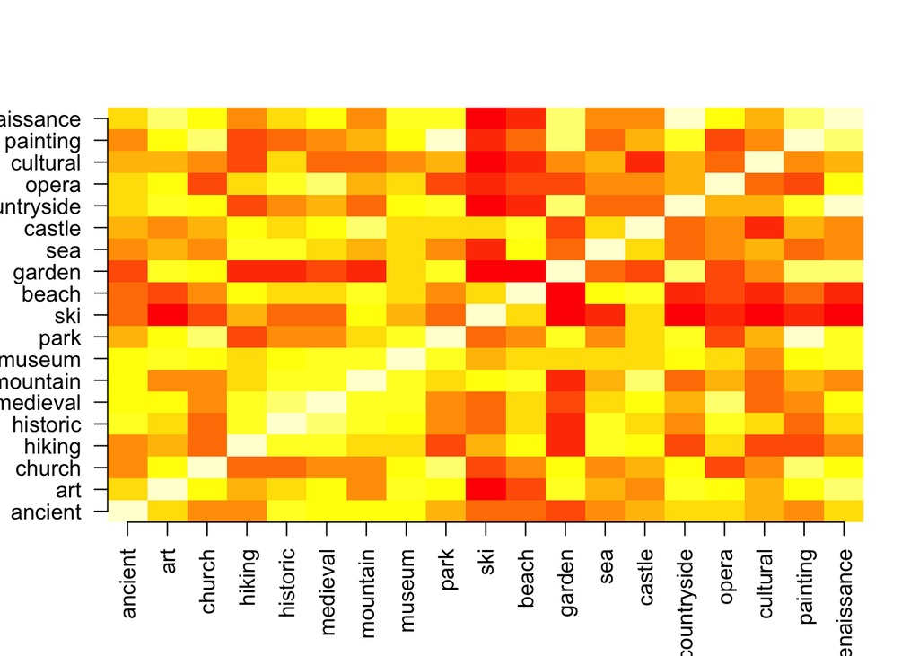

```r
image(cor.mat, axes=F)
axis(1, at=seq(0,1,length.out=length(colnames(cor.mat))),labels=colnames(cor.mat),las=2)
axis(2, at=seq(0,1,length.out=length(colnames(cor.mat))),labels=colnames(cor.mat),las=1)
```

R provides other graphic tools. Using ggplot2, we need to change the input format, with melt:

```r
# install.packages("reshape2")
suppressPackageStartupMessages(library(reshape2))

melted.df <- data.frame(melt(cor.mat))

head(melted.df)
```

|  | Var1 | Var2 | value |
| --- | --- | --- | --- |
| 1 | ancient | ancient | 1.000 |
| 2 | art | ancient | 0.481 |
| 3 | church | ancient | 0.324 |
| 4 | hiking | ancient | 0.349 |
| 5 | historic | ancient | 0.692 |
| 6 | medieval | ancient | 0.670 |

A better visualisation

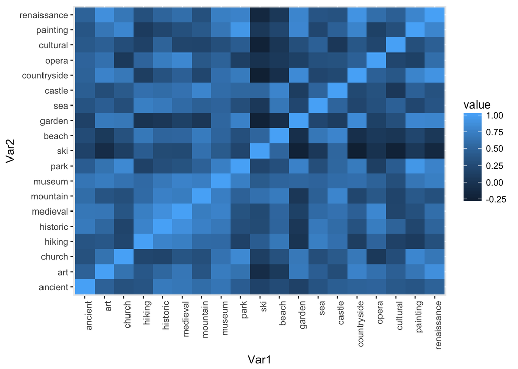

```r
# install.packages("ggplot2")
suppressPackageStartupMessages(library(ggplot2))
qplot(x=Var1, y=Var2, data=melted.df,fill=value, geom="tile") + theme(axis.text.x = element_text(angle = 90, hjust = 1));
```

There are quite a lot of light boxes on the graph - this suggests some keywords are highly correlated and we can cluster them together or group them under topics

# Hierachical Clustering of Keywords

Hierachical Clustering works based on the similarity among data points. A simple choice for a similarity measure would be Euclidean distance (straight-line distance between two points).

The data point pair that has the closest distance between them will be placed together, and the process repeat until all data points are processed.

Let’s run a hierachical clustering on the correlation matrix of our keywords (each word is represented by its correlations with the other words. if the vector of counts accross documents were used to represent keywords, they should probably be adjusted by normalization by keywords or documents for example):

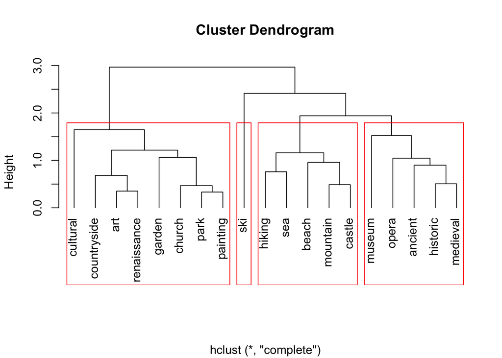

```r
hc <-hclust(dist(cor.mat))  # run the hierachical clustering

plot(hc, hang = -1, xlab = " ")  # plot the dendogram with all words at the bottom

rect.hclust(hc, k = 4, border='red')  # plot the red frame # where k is the number of clusters
```

We get 4 clusters! The four clusters seem to represent ‘Countryside’, ‘Ski’, ‘Outdoors’ and ‘Historic’. Some manual reassignement could be applied if we wished.

Let’s create a mapping table from our tree:

```r
clusters <- 4
themes <- cutree(hc, k = clusters)  # Return each cluster based on the themes
mat.themes=cbind(themes,t(mat))  # Add the column of themes to the termdocument matrix

# Theme document matrix obtained by adding frequency of all words belonging to the themes
thedm=aggregate(mat.themes[,-1],by=list("themes"=mat.themes[,"themes"]),sum)[,-1]
# Manual assignement of the themes
rownames(thedm) <- c("Historic","Countryside","Outdoors","Ski")
thedm
```

|  | Piedmont | Liguria | Lombardy | Aosta_Valley | EmiliaRomagna | FriuliVenezia_Giulia | TrentinoAlto_Adige | Veneto | Lazio | Abruzzo | Marche | Tuscany | Umbria | Apulia | Basilicata | Calabria | Campania | Molise | Sicily | Sardinia |
| --- | --- | --- | --- | --- | --- | --- | --- | --- | --- | --- | --- | --- | --- | --- | --- | --- | --- | --- | --- | --- |
| Historic | 8 | 1 | 5 | 3 | 4 | 1 | 1 | 3 | 2 | 18 | 35 | 8 | 6 | 0 | 0 | 2 | 5 | 0 | 6 | 8 |
| Countryside | 3 | 4 | 4 | 6 | 5 | 3 | 1 | 1 | 3 | 21 | 30 | 59 | 7 | 1 | 0 | 4 | 6 | 0 | 11 | 5 |
| Outdoors | 2 | 9 | 5 | 8 | 11 | 5 | 2 | 2 | 2 | 46 | 33 | 8 | 2 | 3 | 0 | 5 | 3 | 0 | 10 | 32 |
| Ski | 4 | 0 | 3 | 4 | 0 | 2 | 5 | 1 | 0 | 10 | 1 | 0 | 0 | 0 | 0 | 0 | 0 | 0 | 0 | 1 |

# Ranking themes and destinations

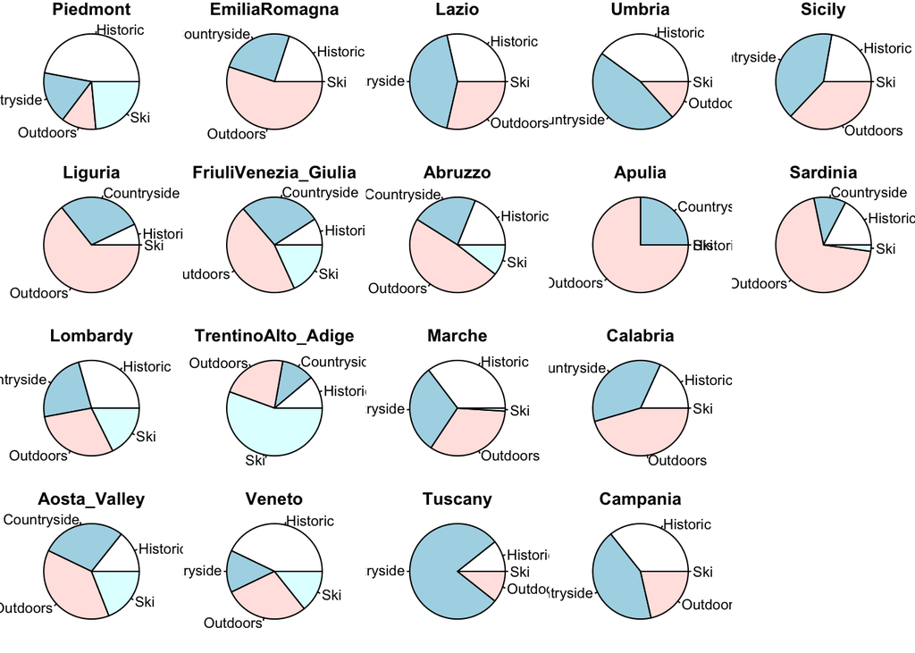

```r
layout(matrix(1:20, nrow=4, ncol=5))
par(mar=c(1,1,1,1))
for (f in names(italy)) {
  if (sum(thedm[,f]) != 0) {
    pie(thedm[,f],labels=rownames(thedm))
    title(f)
  }
}
```